# PEC2_diegoserranoventurini

## 2. Clustering con formas y feature engineering (4 puntos)

Pero no todos los datasets son como los del ejercicio anterior. Para esta segunda parte vamos a emplear el siguiente conjunto de datos:

```python
data_circles = ('circles', *datasets.make_circles(n_samples=N_SAMPLES, factor=.5, noise=.05))
```

Donde *data_circles* es una tupla con tres posiciones: el nombre del dataset y los dos valores devueltos por la función que genera el dataset:

```python
datasets.make_circles?
```

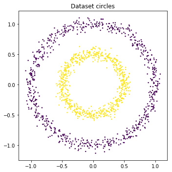

```python
fig, ax = plt.subplots(1, 1, figsize=(5, 5))
ax.scatter(data_circles[1][:,0], data_circles[1][:,1], c=data_circles[2], s=2)
ax.set_title('Dataset {}'.format(data_circles[0]))
plt.tight_layout()
```

### 2 a. Encontrando los clusters con *k-means*

**Implementación:** aplica la regla del codo para decidir el valor de $k$.

[figure not shown]

```python
SSE_circle_results = {}
for k in range(2, 25):
    kmeans = cluster.KMeans(n_clusters=k, n_jobs=-1, max_iter=1000).fit(data_circles[1])
    SSE_circle_results[k] = kmeans.inertia_

plt.figure()
plt.plot(list(SSE_results.keys()), list(SSE_results.values()))
plt.xlabel("Number of cluster")
plt.ylabel("SSE")
plt.show()
```

**Implementación:** aplica *k-means* con el valor de $k$ elegido.  
Visualiza el resultado en un *scatter plot* representando cada cluster con un color distinto.

```python
CIRCLES_K = 20
```

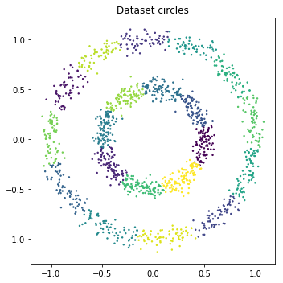

```python
circles_kmeans_results = cluster.KMeans(n_clusters=CIRCLES_K, n_jobs=-1, max_iter=1000).fit_predict(data_circles[1])

fig, ax = plt.subplots(1, 1, figsize=(5, 5))
ax.scatter(data_circles[1][:,0], data_circles[1][:,1], c=circles_kmeans_results, s=2)
ax.set_title('Dataset {}'.format(data_circles[0]))
plt.tight_layout()
```

**Análisis:** ¿Qué ha sucedido? Explica los motivos por los que crees que se ha producido ese resultado.

El modelo ha agrupado conjuntos de puntos cercanos entre si, sin tener en cuenta la distribucion global de los datos.

El algoritmo k-means estima los clusters en funcion unicamente de las distancias entre los puntos y los centroides. Por ello, ante una distribucion como la de estos datos, la distribucion de clusters que minimiza esas distancias es dividir esos circulos en segmentos contiguos.

### 2 b. Más allá de K-Means: algoritmos basados en densidad

En este apartado se pide aplicar clustering por densidad como DBSCAN al dataset anterior para poder encontrar los dos clusters iniciales.

**Implementación:** prueba la implementación de [DBSCAN en scikit-learn](http://scikit-learn.org/stable/modules/generated/sklearn.cluster.DBSCAN.html) jugando con los parámetros *eps* y *min_samples* para encontrar las 2 estructuras subyacentes (y *outliers*).

```python
circles_dbscan_results = cluster.DBSCAN(eps=0.1, min_samples=10).fit_predict(data_circles[1])
```

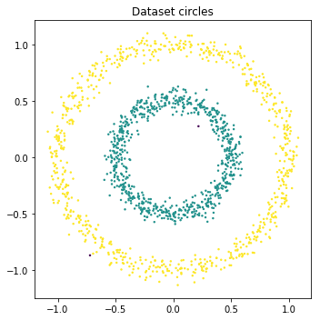

```python
fig, ax = plt.subplots(1, 1, figsize=(5, 5))
ax.scatter(data_circles[1][:,0], data_circles[1][:,1], c=circles_dbscan_results, s=2)
ax.set_title('Dataset {}'.format(data_circles[0]))
plt.tight_layout()
```

**Análisis:** ¿Qué ha sucedido? Explica los motivos por los que crees que se ha producido ese resultado.

Este metodo calcula los clusters encontrando puntos de alta densidad y expandiendo la pertenencia al cluster en base a la distancia a esos puntos densos. Ademas toma en cuenta el numero minimo de registros en cada cluster. Por ello, es capaz de detectar que existen dos zonas densas, las pertenecientes a los circulos, y detectar los *outliers* que son aquellos puntos que no pertenecen a una zona de alta densidad.

### 2 c. Más allá de K-Means: algoritmos jerárquicos

En este apartado se pide visualizar mediante un [dendrograma](https://en.wikipedia.org/wiki/Dendrogram) la construcción progresiva de los grupos mediante un algoritmo jerárquico aglomerativo (estrategia *bottom-up*). Con ello se pretende encontrar un método gráfico para entender el comportamiento del algoritmo y encontrar los dos clusters.

**Implementación:**  
prueba la implementación de [clustering jerárquico de scipy](https://docs.scipy.org/doc/scipy/reference/cluster.hierarchy.html) probando distintos [criterios de enlace o *linkage*](https://en.wikipedia.org/wiki/Hierarchical_clustering#Linkage_criteria) permimtiendo identificar los clusters subyacentes (mostrando su resultado) y su dendrograma.

```python
from scipy.cluster.hierarchy import linkage, dendrogram
```

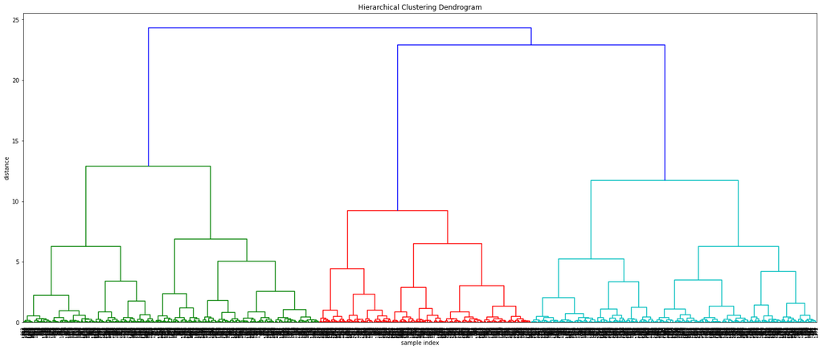

```python
ward_euclidean_agglomerative_results = linkage(data_circles[1], method="ward", metric="euclidean")
# calculate full dendrogram
plt.figure(figsize=(25, 10))
plt.title('Hierarchical Clustering Dendrogram')
plt.xlabel('sample index')
plt.ylabel('distance')
dendrogram(
    ward_euclidean_agglomerative_results,
    leaf_rotation=90.,  # rotates the x axis labels
    leaf_font_size=8.,  # font size for the x axis labels
)
plt.show()
```

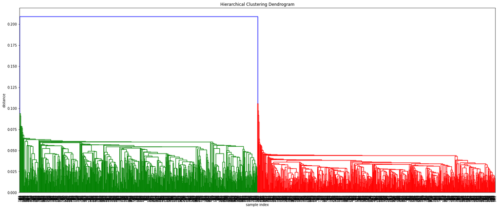

```python
single_euclidean_agglomerative_results = linkage(data_circles[1], method="single", metric="euclidean")
# calculate full dendrogram
plt.figure(figsize=(25, 10))
plt.title('Hierarchical Clustering Dendrogram')
plt.xlabel('sample index')
plt.ylabel('distance')
dendrogram(
    single_euclidean_agglomerative_results,
    leaf_rotation=90.,  # rotates the x axis labels
    leaf_font_size=8.,  # font size for the x axis labels
)
plt.show()
```

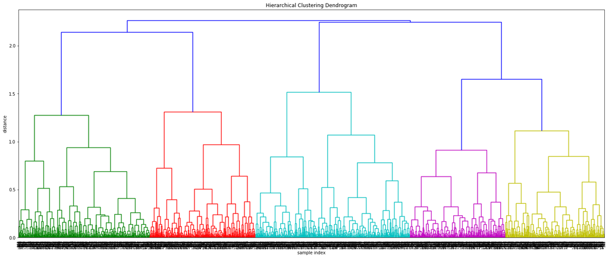

```python
complete_euclidean_agglomerative_results = linkage(data_circles[1], method="complete", metric="euclidean")
# calculate full dendrogram
plt.figure(figsize=(25, 10))
plt.title('Hierarchical Clustering Dendrogram')
plt.xlabel('sample index')
plt.ylabel('distance')
dendrogram(
    complete_euclidean_agglomerative_results,
    leaf_rotation=90.,  # rotates the x axis labels
    leaf_font_size=8.,  # font size for the x axis labels
)
plt.show()
```

**Análisis:** Interpreta el dendrograma y comenta qué criterio de enlace se ha comportado mejor. ¿Por qué?

En el caso del metodo "simple", utilizando la distancia minima, los resultados finales son mas fieles a la distribucion diferenciando practicamente dos unicos clusteres. Por contrapartida, no nos permite diferenciar practicamente puntos entre si. Es decir, si los puntos fueran clientes unicamente podriamos diferenciar entre dos tipos de clientes.

En el caso del metodo "complete", empleando la distancia maxima, el algoritmo aporta mas diversidad de agrupaciones, sin embargo, conociendo la distribucion de los datos, no nos aporta mucha informacion sobre ellos. Es decir, genera la sensacion de que existen 5 grandes clusteres, cuando sabemos que la realidad dista de ser asi.

El tercer metodo, empleando el algortimo Ward de reduccion de la varianza, los resultados son mas ajustados, pero aun asi parece indicar que existen tres clusteres principales.

**Análisis:** ¿Qué ha sucedido? Explica los motivos por los que crees que se ha producido ese resultado.

El metodo simple, une los puntos segun las distancias minimas, esto, similar a lo que ocurria en el algortimo por densidades es capaz de diferenciar entre las dos grandes distribuciones de puntos, ya que existe un gran salto entre los puntos del circulo interior y los del exterior.

Los otros dos metodos, no capturan esa proximidad, y por tanto aportan resultados menos fieles.

### 2 d. *Feature engineering* y agrupamiento

Algunos de los algoritmos anteriores se basan en unas suposiciones que no cumplían en el dataset. Muchas veces en lugar de optar por algoritmos más complejos o que requieren mayor cómputo, se pueden transformar los datos para poder aplicar con éxito técnicas más simples. Esto es un claro ejemplo de *feature engineering*.

**Implementación:** transforma los puntos anteriores del dataset a un nuevo espacio de 2 dimensiones:

- Radio, o distancia al punto (0,0)
- Ángulo,con respecto al vector (1,0)

Para que todas las dimensiones tengan el mismo peso, además vamos a [normalizarlas entre 0 y 1 de acuerdo a su máximo y mínimo](http://scikit-learn.org/stable/modules/generated/sklearn.preprocessing.MinMaxScaler.html).  
Visualizar los puntos del "nuevo" dataset.

```python
from sklearn.preprocessing import MinMaxScaler
```

```python
df_circles = pd.DataFrame(data_circles[1], columns=["x", "y"])
```

```python
df_circles["angle"] = np.arccos(
    np.dot(data_circles[1], [1, 0]) /
    (np.sqrt(np.square(df_circles["x"]) + np.square(df_circles["y"])) )
)
```

```python
df_circles["radius"] = np.sqrt(np.square(df_circles["x"]) + np.square(df_circles["y"]))
```

```python
data_circles_eng = MinMaxScaler().fit_transform(df_circles[["radius", "angle"]].values)
```

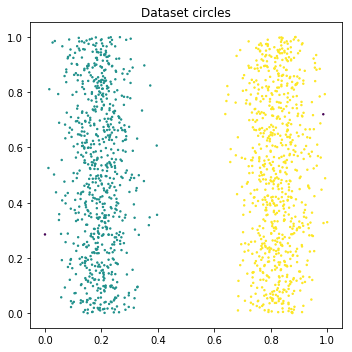

```python
fig, ax = plt.subplots(1, 1, figsize=(5, 5))
ax.scatter(data_circles_eng[:,0], data_circles_eng[:,1], c=circles_dbscan_results, s=2)
ax.set_title('Dataset {}'.format(data_circles[0]))
plt.tight_layout()
```

**Análisis:** ¿Qué crees que sucederá al aplicar los anteriores algoritmos en este "nuevo" dataset?

Con esta transformacion hemos convertido los datos a un espacio en el que los dos circulos deberian estar claramente diferenciados ya que los puntos de cada circulo compartiran un radio similar entre si. Por tanto los algoritmos deberian ser capaces de encontrar los clusteres perfectamente ya que no hay solapamiento de los clusteres en ninguna dimension de este espacio.

**Implementación:** aplica cada uno de los algoritmos de agrupamimento anteriores que no hayan podido localizar adecuadamente los dos clusters originales para tratar de encontrarlos en este "nuevo" espacio. Ajusta los parámetros necesarios para facilitar su detección.  
Para cada algoritmo, visualiza los clusters encontrados en 2 imágenes:

- En el "nuevo" espacio (radio y ángulo).
- En el espacio original (posición x e y), pero NO con las etiquetas (pertenencia al cluster) obtenidas al aplicar los algoritmos sobre el dataset original, sino con las etiquetas obtenidas al realizar el clustering en el "nuevo" espacio. A ver si así se consiguen solventar los problemas iniciales.

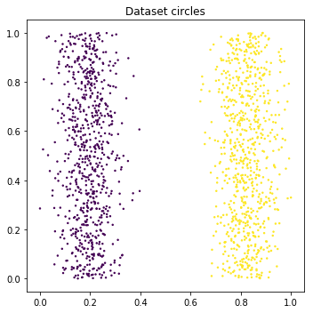

```python
circles_eng_kmeans_results = cluster.KMeans(n_clusters=2, n_jobs=-1, max_iter=500).fit_predict(data_circles_eng)

fig, ax = plt.subplots(1, 1, figsize=(5, 5))
ax.scatter(data_circles_eng[:,0], data_circles_eng[:,1], c=circles_eng_kmeans_results, s=2)
ax.set_title('Dataset {}'.format(data_circles[0]))
plt.tight_layout()
```

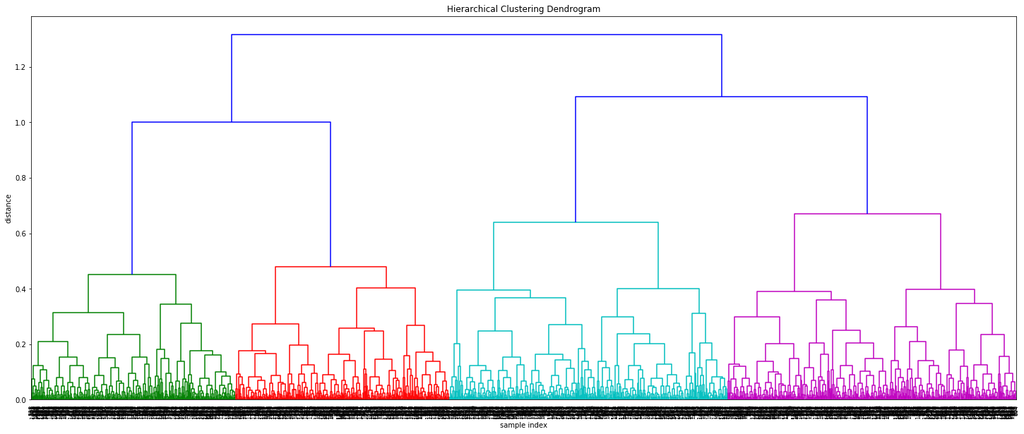

```python
complete_euclidean_agglomerative_results = linkage(data_circles_eng, method="complete", metric="euclidean")
# calculate full dendrogram
plt.figure(figsize=(25, 10))
plt.title('Hierarchical Clustering Dendrogram')
plt.xlabel('sample index')
plt.ylabel('distance')
dendrogram(
    complete_euclidean_agglomerative_results,
    leaf_rotation=90.,  # rotates the x axis labels
    leaf_font_size=8.,  # font size for the x axis labels
)
plt.show()
```

## 3. Reducción de dimensionalidad: PCA y t-SNE (1 punto)

Al plantear un problema de clasificación con un dataset de más de tres atributos (dimensiones), no se puede realizar una visualización clásica del dataset para entender los datos. Por ello, uno de los usos de los métodos de reducción de dimensionalidad es transformar los datos de más de 4 dimensiones a 3 o menos para poder visualizarlos.

### 3 a. PCA

El [dataset Iris](https://es.wikipedia.org/wiki/Iris_flor_conjunto_de_datos) contiene 4 atributos sobre tres tipos de flores.

```python
iris = datasets.load_iris()
X = iris.data   # np.array con shape (150, 4)
y = iris.target # np.array con shape (150,)
```

Al exceder las 3 dimensiones necesitaremos más de una visualización para entender los datos.

Para solucionarlo, una alternativa es usar los [*pair plots*](http://seaborn.pydata.org/generated/seaborn.pairplot.html) que enfrentan pares de dimensiones para tratar de dar una visión global a partir de un [DataFrame](https://pandas.pydata.org/pandas-docs/stable/dsintro.html):

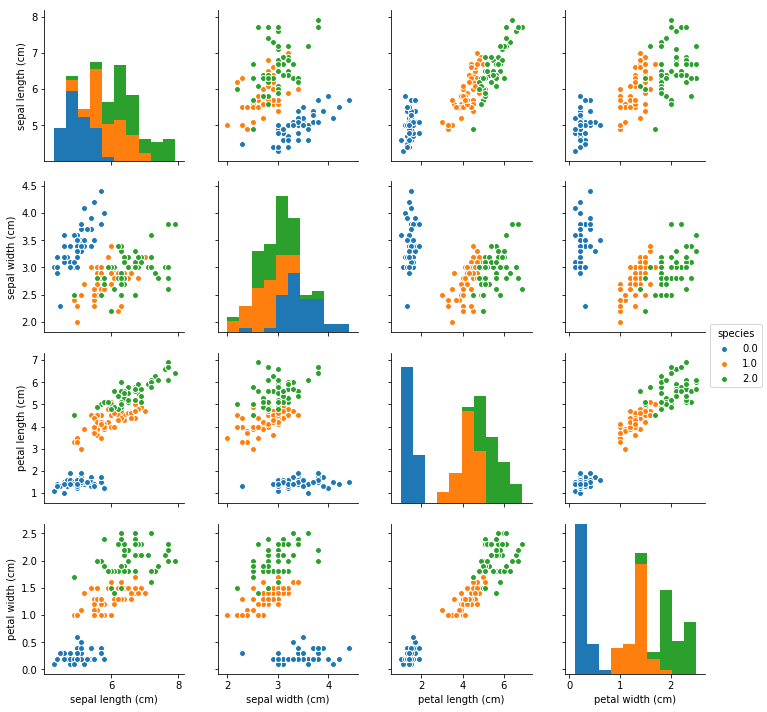

```python
# DataFrame
iris_df = pd.DataFrame(np.hstack([X, y.reshape(-1, 1)]), columns=iris.feature_names + ['species'])
sns.pairplot(iris_df, vars=iris.feature_names, hue="species")
```

Como alternativa a las múltiples gráficas que generan los gráficos pareados, se plantea utilizar una técnica de reducción de dimensionalidad para pasar de 4 dimensiones a 2. Nótese que gráficas como *longitud de pétalo* vs *anchura de pétalo* muestran cierta separabilidad (los 3 tipos de flores están aparentemente separados).

**Implementación:** realizar una reducción de dimensionalidad con PCA para pasar de 4 dimensiones a 2 y crear una visualización donde el color de los puntos dependa del tipo de flor a la que pertenece.

```python
from sklearn.decomposition import PCA
```

```python
iris_pca = PCA(n_components=2, random_state=42).fit_transform(iris_df)
iris_pca_df = pd.DataFrame(np.column_stack((iris_pca, iris_df["species"])), columns=["pca1", "pca2", "species"])
```

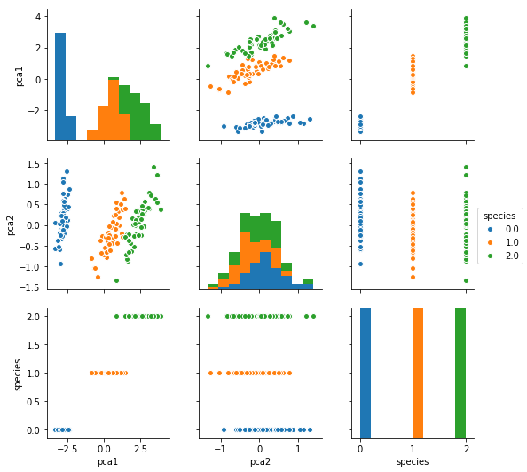

```python
sns.pairplot(iris_pca_df, hue="species")
```

**Análisis:** ¿El resultado de la reducción de dimensionalidad mantiene la separabilidad? ¿Era de esperar? ¿Por qué?

Si. De hecho aumenta la separabilidad de los puntos. En este caso, dado que el numero de variables es bajo, y estas ya contienen informacion, el resultado era de esperar ya que PCA es un metodo que pretende construir vectores que agrupen la varianza. Por tanto, si existen diferencias entre las clases, y dichas diferencias pueden explicarse mediante una combinacion lineal del resto de variables es esperable que las primeras componentes principales magnifiquen esas diferencias.

### 3 b. t-SNE (t-distributed Stochastic Neighbor Embedding)

El uso de técnicas de reducción de dimensionalidad es de gran utilidad cuando esta es muy alta. Por ejemplo, el [dataset Digits](http://scikit-learn.org/stable/auto_examples/classification/plot_digits_classification.html) contiene 1797 imágenes de números del 0 al 9, de 8 por 8 píxeles. Si se toma cada pixel como una dimensión, eso se traduce en que cada muestra tiene ¡64 dimensiones!

```python
digits = datasets.load_digits()
X = digits.data   # np.array con shape (1797, 64)
y = digits.target # np.array con shape (1797,)
```

Ejemplo de los 24 primeros dígitos de 8 por 8 píxeles junto a su etiqueta presentes en el dataset:

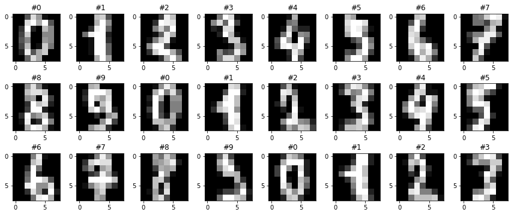

```python
fig, ax = plt.subplots(3, 8, figsize=(12, 5))
for i, axis in zip(range(24), ax.reshape(-1)):
    axis.imshow(X[i,:].reshape(8, 8), cmap='gray')
    axis.set_title('#{}'.format(y[i]))
plt.tight_layout()
```

Con un número tan elevado de dimensiones pierde sentido visualizar el dataset con un *pair plot* y aparecen otros peligos como la [maldición de la dimensionalidad](https://es.wikipedia.org/wiki/Maldici%C3%B3n_de_la_dimensi%C3%B3n). Para reducir su dimensión y así entender la estructura de los datos en alta dimensionalidad existen distintas alternativas con resultados muy distintos.

**Implementación:** realizar una reducción de dimensionalidad con PCA para pasar de 64 dimensiones a 2 y crear una visualización donde el color de los puntos dependa del dígito que pertenece.

```python
X_pca = PCA(n_components=2, random_state=42).fit_transform(X)
X_pca_df = pd.DataFrame(np.column_stack((X_pca, y)), columns=["pca1", "pca2", "value"])
```

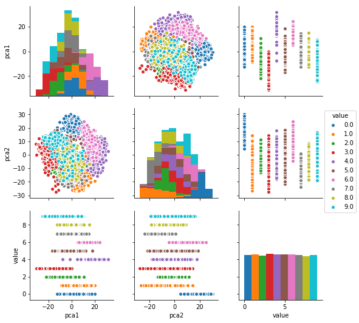

```python
sns.pairplot(X_pca_df, hue="value")
```

**Análisis:** ¿El resultado de la reducción de dimensionalidad mantiene la separabilidad? ¿Era de esperar? ¿Por qué?

En este caso vemos que la division no existe. Se trata de un conjunto de datos mas complejo, ya que las variables son la intensidad de cada uno de los pixeles, es decir, tenemos 64 variables con un rango de valores mayor para identificar las clases. Por tanto, las posibilidades de que una combinacion lineal de estas 64 variables explique una division de 10 clases es mucho menor. A pesar de que las diferencias son minimas, la reduccion de dimensionalidad si agrupa los elementos de una misma clase cerca entre si.

El algoritmo [t-SNE](https://en.wikipedia.org/wiki/T-distributed_stochastic_neighbor_embedding) ideado por [van der Maaten y Hinton](https://lvdmaaten.github.io/tsne/) difiere de PCA en que no trata de maximizar la varianza explicada. Intuitivamente, t-SNE trata de que la vecindad de un punto en baja dimensionalidad sea la misma que la original. Partiendo de una localización aleatoria de cada punto, corrige su posición de forma iterativa tratando de minimizar la distancia a sus vecinos originales hasta converger.

Para ello, t-SNE dispone de diversos [parámetros](https://distill.pub/2016/misread-tsne/) que pueden modificar drásticamente el resultado. Por lo que se recomienda conocer su funcionamiento antes de aplicar la técnica.

**Implementación:** realizar una reducción de dimensionalidad con t-SNE para pasar de 64 dimensiones a 2 y crear una visualización donde el color de los puntos dependa del dígito que pertenece.

```python
from sklearn.manifold import TSNE
```

```python
X_tsne = TSNE(n_components=2, random_state=42).fit_transform(X)
X_tsne_df = pd.DataFrame(np.column_stack((X_tsne, y)), columns=["dim1", "dim2", "value"])
```

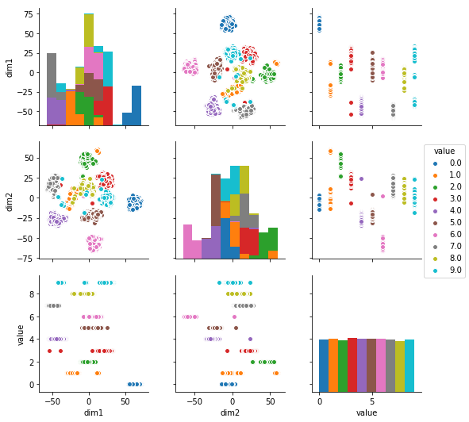

```python
sns.pairplot(X_tsne_df, hue="value")
```

**Análisis:** ¿El resultado de la reducción de dimensionalidad mantiene la separabilidad? ¿Era de esperar? ¿Por qué?

Este metodo genera una reduccion de dimensionalidad que si mantiene la separabilidad. A diferencia de PCA, el metodo TSNE genera las variables sinteticas combinando las variables no-linealmente. De esta manera se emplean las 64 variables proporcionadas para construir una representacion de los datos que si permite diferenciar practicamente las clases (salvo un aparente solapamiento entre los numeros 1, 9 y 8)

## 4. Aplicación: Agrupación de documentos (3 puntos)

### 4 a. Carga y limpieza de datos

En este problema se utilizará el dataset [*20 news group*](https://archive.ics.uci.edu/ml/machine-learning-databases/20newsgroups-mld/20newsgroups.data.html), con 20 categorías de textos, de los cuales se seleccionarán 3. El objetivo es encontrar grupos de textos (preferiblemente de la misma categoría) a través de sus palabras.

El primer apartado consiste en cargar el dataset y limpiar los datos (tarea que normalmente tiene una carga entre el 70 y 80% del tiempo), en este caso los textos.

```python
data = datasets.fetch_20newsgroups(categories=['rec.autos', 'rec.sport.baseball', 'soc.religion.christian'])
texts, targets = data['data'], data['target']
```

Donde `texts` es una lista con los artículos y `targets` es un vector con el índice de la categoría a la que pertenece cada texto.

La limpieza de texto debe convertir:

```python
print(data['data'][0])
```

```
From: caralv@caralv.auto-trol.com (Carol Alvin)
Subject: Re: The arrogance of Christians
Lines: 88

vbv@r2d2.eeap.cwru.edu (Virgilio (Dean) B. Velasco Jr.) writes:
> In article <Apr.13.00.08.35.1993.28412@athos.rutgers.edu> caralv@caralv.auto-trol.com (Carol Alvin) writes:
> > (Virgilio (Dean) B. Velasco Jr.) writes:
> >> (Carol Alvin) writes:
> >> > ...
> >> >Are all truths also absolutes?
> >> >Is all of scripture truths (and therefore absolutes)?
> >> >
> >> The answer to both questions is yes.
> >
> > ...
> >an absolute is something that is constant across time, culture,
> >situations, etc.  True in every instance possible.  Do you agree
> >with this definition? ...
> >
> Yes, I do agree with your definition.  ...
>
> > [example of women covering their heads and not speaking]
>
> Hold it.  I said that all of scripture is true.  However, discerning
> exactly what Jesus, Paul and company were trying to say is not always so
> easy.  I don't believe that Paul was trying to say that all women should
> behave that way.  Rather, he was trying to say that under the circumstances
> at the time, the women he was speaking to would best avoid volubility and
> cover their heads.  This has to do with maintaining a proper witness toward
> others.  Remember that any number of relativistic statements can be derived
> from absolutes.  For instance, it is absolutely right for Christians to
> strive for peace.  However, this does not rule out trying to maintain world
> peace by resorting to violence on occasion.  (Yes, my opinion.)

I agree that there is truth in scripture.  There are principles to be
learned from it.  Claiming that that truth is absolute, though, seems
to imply a literal reading of the Bible.  If it were absolute truth
(constant across time, culture, etc.) then no interpretation would be
necessary.

```

[output cut: 37 more lines]

```
than yours.  :-)

So, I think that your position is:
The Bible is absolute truth, but as we are prone to error in our
interpretation, we cannot reliably determine if we have figured out
what that truth is.
Did I get that right?

What's the point of spending all this time claiming and defending
absolute truth, when we can never know what those truths are, and we
can never (or at least shouldn't) act upon them?  What practical
difference can this make?

Carol Alvin
caralv@auto-trol.com
```

En algo muy parecido a:

`In previous article UUCP wharfie says In article centerline com com Jim Frost writes larger engine That's what the SHO is slightly modified family sedan with powerful engine They didn't even bother improving the *brakes That shows how much you know about anything The brakes on the SHO are very different inch or forget discs all around vented in front The normal Taurus setup is smaller discs front drums rear one saw had vented rears too it was on lot of course the sales man was fool titanium wheels yeah right then later told me they were magnesium more believable but still crap since Al is so uch cheaper and just as good tend to agree tho that this still doesn't take the SHO up to standard for running 130 on regular basis The brakes should be bigger like 11 or so take look at the ones on the Corrados where they have braking regulations DREW`

**Implementación:** limpia los textos de entrada:

- Elimina las líneas de encabezado.
- Los signos de puntuación.
- Los corchetes, paréntesis y angulares.
- Los saltos de línea.
- Exclamaciones e interrogaciones.
- Los tokens e-mails y de longitud 1.
- Los espacios en blanco consecutivos.

```python
import re
```

```python
texts_preprocessed = [re.sub(' +',' ', re.sub(r"[^a-zA-Z0-9]", " ", " ".join(txt.split("\n\n")[1:]))).lower()
                        for txt in texts]
```

### 4 b. Conversión de textos a vectores

Para encontrar grupos entre los textos, es necesario convertir cada texto en un vector. Existen multitud de maneras de hacerlo, una de ellas es aplicar [TF-IDF](https://en.wikipedia.org/wiki/Tf%E2%80%93idf) con scikit-learn [TfidfVectorizer](http://scikit-learn.org/stable/modules/generated/sklearn.feature_extraction.text.TfidfVectorizer.html). Transformando la lista de textos en una [matriz dispersa](https://docs.scipy.org/doc/scipy/reference/sparse.html) con tantas filas como artículos y tantas columnas como palabras.

**Implementación:** transforma los textos a vectores con TF-IDF. Para reducir el número de columnas en la matriz evita las *stop words* en inglés y convierte los textos a minúsculas.

```python
from sklearn.feature_extraction.text import TfidfVectorizer
```

```python
X_texts = TfidfVectorizer(stop_words="english").fit_transform(texts_preprocessed)
```

### 4 c. Reducción de dimensionalidad

Para visualizar y encontrar los grupos, se reducirá la dimensionalidad de la matriz anterior. De tal forma que el número de columnas se reducirá a 2 (el número de filas se mantiene, ya que cada fila es un documento).

**Implementación:** utiliza t-SNE para reducir la dimensionalidad de *n* columnas (palabras) a 2 dimensiones. Utiliza un tamaño de perplejidad alto para aumentar la vecindad (en torno a 100).

```python
X_texts_tsne = TSNE(n_components=2, random_state=42, perplexity=100).fit_transform(X_texts.toarray())
X_texts_tsne = pd.DataFrame(np.column_stack((X_texts_tsne, targets)), columns=["dim1", "dim2", "target"])
```

**Implementación:** visualiza mediante un scatter plot los puntos en 2 dimensiones con un color para cada clase.

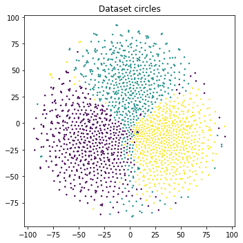

```python
fig, ax = plt.subplots(1, 1, figsize=(5, 5))
ax.scatter(X_texts_tsne["dim1"], X_texts_tsne["dim2"], c=X_texts_tsne["target"], s=2)
ax.set_title('Dataset {}'.format(data_circles[0]))
plt.tight_layout()
```

### 4 d. Encuentra los grupos de artículos con distintos algoritmos

**Implementación:** utiliza *k-means* (con *k=3*) para tratar de encontrar los 3 grupos de artículos y visualiza el resultado.

```python
texts_kmeans_clusters = cluster.KMeans(n_clusters=3, n_jobs=-1, max_iter=1000).fit_predict(X_texts)
```

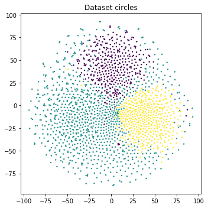

```python
fig, ax = plt.subplots(1, 1, figsize=(5, 5))
ax.scatter(X_texts_tsne["dim1"], X_texts_tsne["dim2"], c=texts_kmeans_clusters, s=2)
ax.set_title('Dataset {}'.format(data_circles[0]))
plt.tight_layout()
```

**Análisis:** ¿Ha localizado los 3 grupos originales? (el color no tiene porque coincidir, solo nos importa la forma) ¿Por qué?

El algoritmo ha encontrado los grupos originales. Como vemos, en el mismo espacio generado por el TSNE, hemos visualizado los clusters y corresponden en un % alto a las clases originales. La representacion del dataset generada mediante TfIdf a pesar de ser muy dispersa es un espacio en el que la distancia euclidea sirve para comparar textos. Representaciones de los textos mas densas como *embeddings* tiende a mejorar estos resultados.

Para agrupar los textos tratando de situar los centroides en las regiones más densas, [Mean-Shift](http://scikit-learn.org/stable/modules/generated/sklearn.cluster.MeanShift.html) sigue un camino desde cualquier punto del espacio guiándose por la densidad de puntos hasta alcanzar un máximo local (dentro de su *bandwidth*).

**Implementación:** utiliza *Mean-Shift* (variando en *bandwidth*) hasta encontrar 3 grupos y visualiza el resultado.

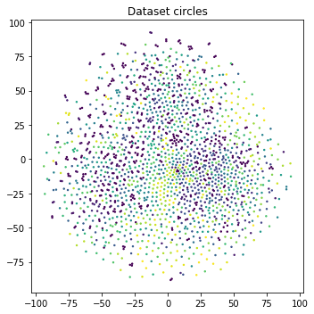

```python
texts_mean_shift_clusters = cluster.MeanShift(n_jobs=-1, bandwidth=0.925).fit_predict(X_texts.toarray())
fig, ax = plt.subplots(1, 1, figsize=(5, 5))
ax.scatter(X_texts_tsne["dim1"], X_texts_tsne["dim2"], c=texts_mean_shift_clusters, s=2)
ax.set_title('Dataset {}'.format(data_circles[0]))
plt.tight_layout()
```

**Análisis:** ¿Ha localizado los 3 grupos originales? (el color no tiene porque coincidir, solo nos importa la forma) ¿Por qué?

No. Segun explica la documentacion proporcionada, el metodo se basa en la densidad de los puntos en el espacio. Como se comento en el apartado anterior, TfIdf genera un espacio en el que la distancia euclidea es "efectiva" pero poco denso. Por tanto, este metodo, no es capaz re-construir los clusteres originales.